# Healthcare - análisis eploratorio

Martín Pons

16/5/2020

Análisis exploratorio de topics relacionados con el sistema sanitario a partir de datos recogidos de twitter, con la consulta ‘healthcare’

## Configuracion inicial

```r
# librerias
library(qdapRegex)
library(sentimentr)
library(syuzhet)
library(lubridate)
library(tidyverse)
library(tidytext)
library(forcats)
library(tokenizers)
library(widyr)
library(igraph)
library(ggraph)
library(topicmodels)
library(forcats)
library(scales)
library(stringr)
library(extrafont)
library(reldist)
library(grid)
library(gridExtra)
library(boot)
library(ggradar)
library(tidygraph)
library(boot)
# Sys.getenv()
Sys.setenv(JAVA_HOME = "C:\\Program Files\\Java\\jre1.8.0_251")

library(tm)
library(qdap)

# funciones auxiliares
source(here::here("scripts", "funciones_auxiliares.R"))

# paleta
plots_palette <- c("#ad5d51", "grey55", "#2b559e", "#947240")

# orden comunidades
comunidad_order <- c("GOP", "Independent", "DNC", "Progressives")
```

## Distribucion de tweets

Carga de datos. Estos datos han sido previamente procesados, sobre todo en lo que se refiere al texto de los tweets. Se excluyen términos relacionados con la pandemia que provoca la enfermedad COVID-19 (en el texto sin limpiar, hay un número amplio de términos para referirse a la enfermedad. Se han unificado todos en el término COVID19).

Se ha recogido también información sobre los seguidores de cuentas para definir 4 comunidades

- GOP: Seguidores de la cuenta del partido republicano, que no siguen la cuenta del partido demócrata ni del movimiento progresista
- DNS: Seguidores de la cuenta del partido demócrata, que no siguen la cuenta del partido republicano ni del movimiento progresista
- Progressives: Seguidores de la cuenta del movimiento progresista, que no siguen la cuenta del partido republicano ni del partido demócrata
- Independent: usuarios de tweets recogidos que no se encuentran incluidos en ninguno de los casos anteriores

```r
healthcare <- readRDS(here::here("datos_procesados", "formated_text_df_data", "healthcare.rds")) %>%
  filter(str_detect(text, "#?covid19|#?COVID|#?[Pp]andemic", negate = T)) %>%
  mutate(comunidad = fct_relevel(comunidad, c("GOP", "Independent", "DNC", "Progressives")))
```

El número todal de tweets únicos recogidos, sin incluir retweets es de 248.595.

Vemos también que los tweets pertenecientes a las comunidades no independientes son minoría

```r
healthcare %>%
  count(comunidad) %>%
  mutate(Porcentaje = percent(n /sum(n), accuracy = 0.1))
```

```
## # A tibble: 4 x 3
##   comunidad         n Porcentaje
##   <fct>         <int> <chr>
## 1 GOP           13252 5.3%
## 2 Independent  205112 82.5%
## 3 DNC           15862 6.4%
## 4 Progressives  14369 5.8%
```

Un reducido grupo de usuarios publica la mayoría de los tweets. Para todos los grupos, un 5 % de los usuarios publica al menos un 97 % de los weets

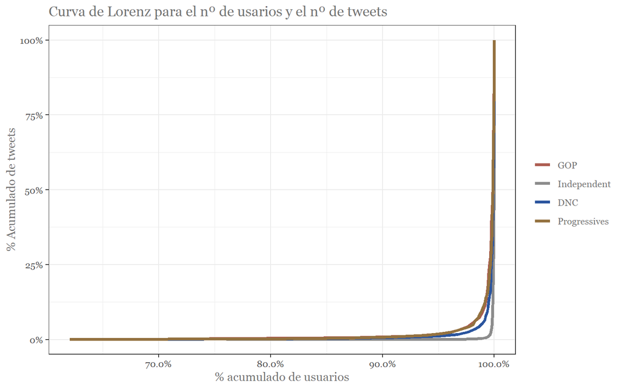

```r
# sentimiento
freq_tweets_usuario <- get_tweet_distribution(healthcare)

# Curva de lorenz
freq_tweets_usuario %>%
  ggplot(aes(x = porc_usuarios_acum, y = porc_tweets_acum)) +
  geom_line(aes(color = comunidad), size = 1.3) +
  scale_color_manual(values = plots_palette) +
  labs(x = "% acumulado de usuarios", y = "% Acumulado de tweets",
       title = "Curva de Lorenz para el nº de usarios y el nº de tweets") +
  scale_x_continuous(labels = scales::percent) +
  scale_y_continuous(labels = scales::percent) +
  theme_bw() +
  theme(text = element_text(family = "Georgia", color = "grey45"),
        legend.title = element_blank())
```

```r
# gini
gini_comunidades <- freq_tweets_usuario %>%
  group_by(comunidad) %>%
  summarise(gini = gini(x = tweets, weights = porc_usuarios)) %>%
  arrange(desc(gini))
```

## Analisis de Topic

### Hashtags más usados

Los tweets varían dependiendo de la comunidad de referencia, en el Partido Republicano abunda el apoyo a trump,y otros temas políticos co como a reivindicación de la apertura del pais (#openamericanow) y alguna teoría conspirativa (#obamagate). En los tweets del partido demócrata también abundan temas de apoyo poloítico, mientras que la práctica mayoría de los tweeets de los progresistas están dedicados a la iniciativa Medicare for All.

Las network graficadas representan las relaciones entre hashtags: cuando dos hastags están unidos quiere decir que están incluidos en el mismo tweet.

```r
healthcare_unigram <- get_unigrams(healthcare,c("#healthcare", "healthcare"))
healthcare_hashtag <- get_hashtags(healthcare_unigram)
healthcare_frequency <- get_frequencies(healthcare_hashtag)

gop_hash_net <- create_hashtag_graph(healthcare_hashtag, "GOP", c("#health"), minim_n = 3)
```

[output not shown]

```r
dnc_hash_net <- create_hashtag_graph(healthcare_hashtag, "DNC", c("#health"), minim_n = 3)
```

[output not shown]

```r
prg_hash_net <- create_hashtag_graph(healthcare_hashtag, "Progressives", c("#health"), minim_n = 3)
```

[output not shown]

```r
health_graph <- bind_graphs(gop_hash_net, dnc_hash_net, prg_hash_net) %>%
  activate(nodes) %>%
  mutate(comunidad = fct_relevel(comunidad, c("GOP", "DNC", "Progressives")))
```

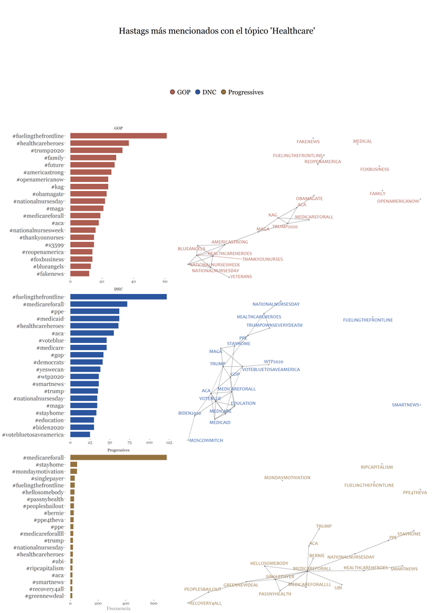

```r
## IDEA PARA MEJOR VISUALIZACIÓN : ELIMINAR NODOS AISLADOS!!!!!!!

grob_bars <- ggplotGrob(plot_topics(healthcare_frequency %>% filter(comunidad != "Independent"),
                                    c("#health"),
                                    cols = 1, colores = c(1, 3, 4)) +
                          guides(fill = F) +
                          labs(x = "Frecuencia") +
                          theme(axis.title.y = element_blank(),
                                axis.text.y = element_text(size = 16)))


set.seed(123)
grob_graph <- ggplotGrob(health_graph %>%
  ggraph(layout = "nicely") +
  geom_edge_link(alpha = 0.5) +
  geom_node_point(alpha = 0.3) +
  geom_node_text(aes(label = nodes, color = comunidad), size = 4.8, family = "Candara", repel = T) +
  facet_nodes(~comunidad, ncol = 1, scales = "free") +
  theme_bw() +
  guides(color = F) +
  scale_color_manual(values = plots_palette[c(1, 3, 4)]) +
    theme(panel.grid = element_blank(),
          strip.background = element_blank(),
          strip.text = element_text(family = "Georgia", size = 11, color = "white"),
          panel.border = element_blank(),
          axis.title = element_blank(),
          axis.text = element_blank(),
          axis.ticks = element_blank()))


titulo <-  textGrob(label = "Hastags más mencionados con el tópico 'Healthcare'", gp = gpar(fontfamily = "Georgia", cex = 2))
leyenda <- legendGrob(labels = c("GOP",  "DNC", "Progressives"),  pch = 21,
                      gp = gpar(fill = plots_palette[c(1, 3, 4)], fontfamily = "Georgia", cex = 1.5), nrow = 1)

plots_grob = arrangeGrob(grob_bars, grob_graph, nrow = 1, widths = c(4, 6))

grid.arrange(titulo, leyenda, plots_grob, heights = c(1, 1, 8))
```

```r
# plot_topics(healthcare_frequency, c("#covid19", "#health"))
```

En el GOP, parecen haber tres temas diferentes: temas relacionados ocn los trabajadores sanitarios, temas de campaña política y temas de posición política en relación al COVID19. En el DNC, la distinción es menor pero también se pueden apreciar dos temas: capaña política y trabajadores sanitarios.

En el movimiento progrsista todo está centrado alrededor de Medicare for All.

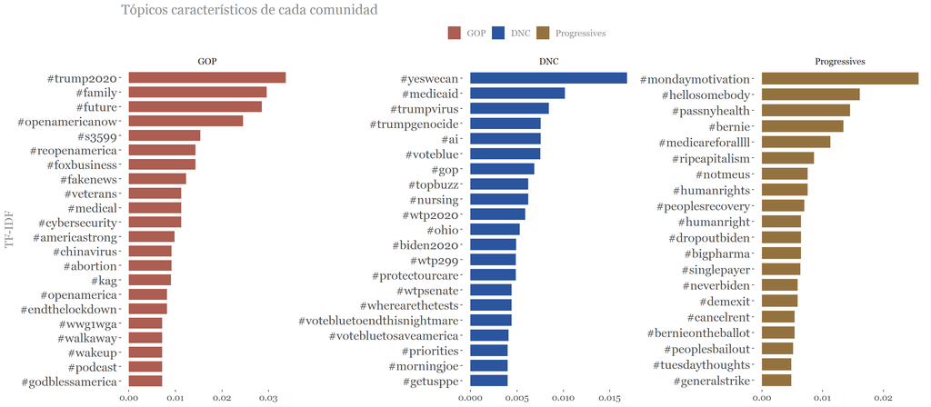

```r
healthcare_tfidf_hashtags <- get_tfidf(healthcare_frequency %>% filter(comunidad!= "Independent"))

plot_tfidf(healthcare_tfidf_hashtags, cols = 3, colores = c(1, 3, 4)) +
  labs(title = "Tópicos característicos de cada comunidad", y = "TF-IDF") +
  theme(axis.title.x= element_blank(),
        axis.text.y = element_text(size = 15),
        legend.title = element_blank())
```

Además para todos los grupos aparecen terminos característicos, por ejemplo #abortion, #veterans en el partido republicano. Acompañados de terminos relacionados con posibles teorías de la conspiracion relacionadas con la pandemia COVID19 como #chinavirus, #wakeup o #fakenews.

Por parte de los progresistas, destaca el hashtag #neverbiden, más otros terminos asociados con ideología política de de izquierda reivindicativa (#generalstrike, #humanright).

Finalmente, entro los hashtags diferenciales de los demócreatas aparecen en las primeras posiciones hashtags de connotación negativa relacionados con el presidente Donald Trump.

### Análisis de “Medicare for all”

Todos los movimientos políticos hacen referencia aL tópico #medicareforall. Observaresmos más en profundidad la opinión de las comunidades acerca de esta iniciativa política. Empecemos con el análisis de sentimiento.

Para ello haremos uso de otro set de datos descargados con tweets referentes a este tema.

Como es u n tema propicio a generar opiniones contrapuestas, excluiremos tweets con hashtags que pueden hacer referencia a otras políticas sanitarias, como por ejemplo el Affodable Care Act (ACA).

Los datos que se cargan aquí ya tienen el sentimiento de cada tweet, calculado en la fase de limpieza de datos.

```r
# carga de datos
mfa <- readRDS(here::here("datos_procesados", "formated_text_df_data", "medicareforall.rds"))

# Exclusion de tweets con terminos referentes a otras políticas sanitarias
exclusion_mfa <- "#medicaid|#aca|[Aa]ffordable ?[Cc]are ?[Aa]ct|#publicoption|[Pp]ublic ?[Oo]ption|#medicare( |$|#)|#?COVID|#[Pp]andemic"
mfa <- mfa %>%
  filter(discriminate_term(text, "#medicareforall|#m4a", exclusion_mfa))
```

En la siguiente tabla se presenta el sentimiento medio sobre medicar for all

```r
mfa_sent <- mfa %>%
  group_by(comunidad) %>%
  summarise(sent = mean(ave_sentiment),
            n = n()) %>%
  mutate(f = percent(n/sum(n), accuracy = 0.1))
mfa_sent
```

```
## # A tibble: 4 x 4
##   comunidad        sent     n f
##   <chr>           <dbl> <int> <chr>
## 1 DNC           0.0498    526 4.7%
## 2 GOP          -0.0593     99 0.9%
## 3 Independent   0.00770  4404 39.2%
## 4 Progressives  0.0295   6220 55.3%
```

Los resultaos reflejan por parte de los progresistas una valoración de medicare for all, menor que los demócratas (sin comprobar si esta diferencia es estadísticamente significativa). Algo que en un principio puede sorprender, pero en realidad #medicareforall se ha empezado a convertir en una marca en el partido demócrata que puede querer decir diferentes cosas según el emisor del mensaje.

Comprobemos que otros tópicos de política sanitaria se pronuncian cuando se habla de #medicareforall

```r
# limpieza de topicos
mfa_healthcare_clean <- mfa %>%
  mutate(text = str_replace_all(text, "single payer", "singlepayer")) %>%
  mutate(text = str_replace_all(text, "public option", "publicoption")) %>%
  mutate(text = str_replace_all(text, "(obama ?care)|(affordable ?care ?act)", "aca")) %>%
  mutate(text = str_replace_all(text, "#", "")) %>%
  filter(str_detect(text, "singlepayer|publicoption|aca|medicaid|medicare"))

# creacion de tabla de unigrams
mfa_clean_unigram <- get_unigrams(mfa_healthcare_clean %>% filter(comunidad != "Independent")) %>%
  filter(word %in% c("singlepayer", "publicoption", "aca", "medicaid", "medicare"))

# tabla de frecuencias de los uunigrams
mfa_clean_freq <- get_frequencies(mfa_clean_unigram) %>%
  left_join(mfa %>%
             group_by(comunidad) %>%
             count(name = "tweets"), by = "comunidad") %>%
  mutate(f = n / tweets)
```

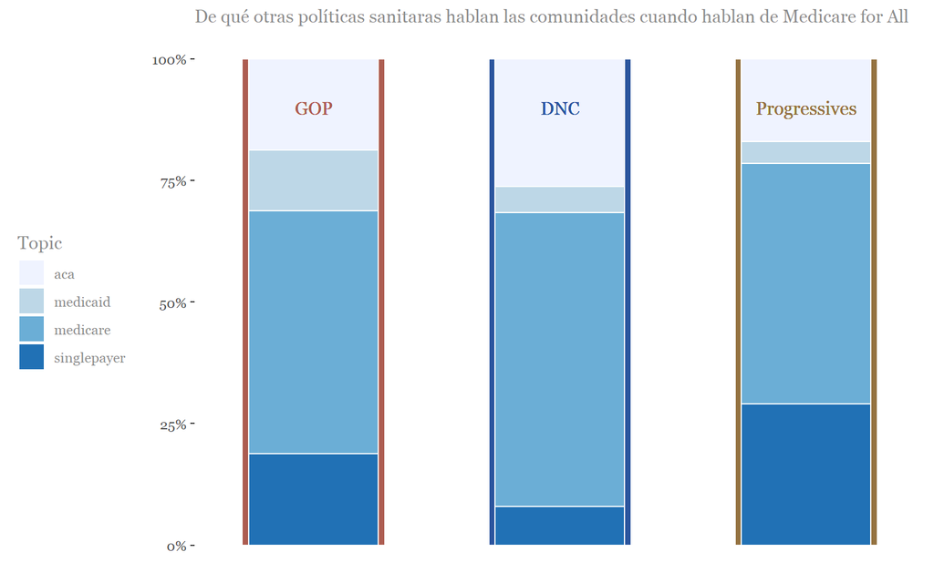

```r
# grafico
mfa_clean_freq %>%
  ungroup() %>%
  mutate(comunidad = fct_relevel(comunidad, c("GOP",  "DNC", "Progressives"))) %>%
  ggplot() +
  geom_rect(data = data.frame(xmin = 0.67,
                              xmax = 1.33,  ymin = 0,
                              ymax = 1,
                              comunidad = factor(c("GOP",  "DNC", "Progressives"))),
            aes(xmin = xmin, xmax = xmax, ymin = ymin, ymax = ymax),
            fill = plots_palette[c(1, 3, 4)], alpha = 1,
            color = "white") +
  geom_col(aes(x = 1, y = f,fill = fct_reorder2(word, f, comunidad)), position = "fill",
           color = "white", width = 0.6) +
  geom_text(x = 1, y = 0.9, aes(label = comunidad, color = comunidad),
            family = "Georgia",
            size = 4) +
  labs(fill = "Topic") +
  facet_wrap(~comunidad, nrow = 1) +
  theme_bw() +
  theme(panel.grid = element_blank()) +
  scale_fill_brewer() +
  guides(color = F) +
  theme_bw() +
  theme(
    text = element_text(family = "Georgia", color = "grey55"),
    plot.title = element_text(size = 11),
    panel.grid = element_blank(),
        panel.border = element_blank(),
        strip.background = element_blank(),
    strip.text = element_blank(),
        legend.position = "left",
        axis.title.x = element_blank(),
        axis.text.x = element_blank(),
        axis.ticks.x = element_blank(),
    axis.title.y = element_blank()) +
  scale_x_continuous(limits = c(0.5, 1.5)) +
  scale_y_continuous(label = scales::percent) +
  scale_color_manual(values = plots_palette[c(1, 3, 4)]) +
  labs(title = "De qué otras políticas sanitaras hablan las comunidades cuando hablan de Medicare for All")
```

Aunque en todos los casos el tema más abundante es Medicare, el programa sanitario para jubilados, los progresistas hablan sustancialmente más que los Demócratas sobre la política Single Payer: iniciativa sanitaria del senador Bernie Sanders, que determina el gobierno sería el pagador único de la sanidad, de modo que consecuentemente, se eliminarían los seguros sanitarios privados (en contraste, algunos candidatos demócratas emplean Medicare for All como sinónimo de la política “Public Option”: un progama de sanidad universal pero que conviviría con seguros sanitarios privados). En contraste, los demócratas hablan más del Affordable Care Act (ACA), también conocido como “Obama Care”: el plan sanitario aprobado durante el gobierno de Barak Obama.

Examinemos pues la percepción del programa Single Payer en las distintas comunidades. Para ello cargaremos otro set de datos recogido expresamente de twitter con tweets que contienen el término “singlepayer”

### Análisis del sentimiento de “SinglePayer”

Analizaremos el sentimiento expresado en los tweets recogidos. Como en el caso de Medicare for All, en el análisis eliminaremos tweets que hagan referencia a otras políticas sanitarias diferentes.

```r
# carga de datos
sp <- readRDS(here::here("datos_procesados", "formated_text_df_data", "singlepayer.rds")) %>%
  mutate(comunidad = fct_relevel(comunidad, comunidad_order))

# filtro de tweets con politicas sanitarias no compatibles con sigle payer
exclusion_sp <- "#medicaid|#aca|[Aa]ffordable ?[Cc]are ?[Aa]ct|#publicoption|[Pp]ublic ?[Oo]ption|#medicare( |$|#)|#COVID|COVID"
sp <- sp %>%
  filter(discriminate_term(text, "[Ss]ingle ?[Pp]ayer", exclusion_sp))
```

```r
sp_sent <- sp %>%
  filter(comunidad != "Independent") %>%
  group_by(comunidad) %>%
  summarise(sent = mean(ave_sentiment),
            n = n()) %>%
  mutate(f = percent(n / sum(n), accuracy = 0.1))
sp_sent
```

```
## # A tibble: 3 x 4
##   comunidad        sent     n f
##   <fct>           <dbl> <int> <chr>
## 1 GOP          -0.00456   136 12.1%
## 2 DNC           0.0266    190 16.8%
## 3 Progressives  0.0664    802 71.1%
```

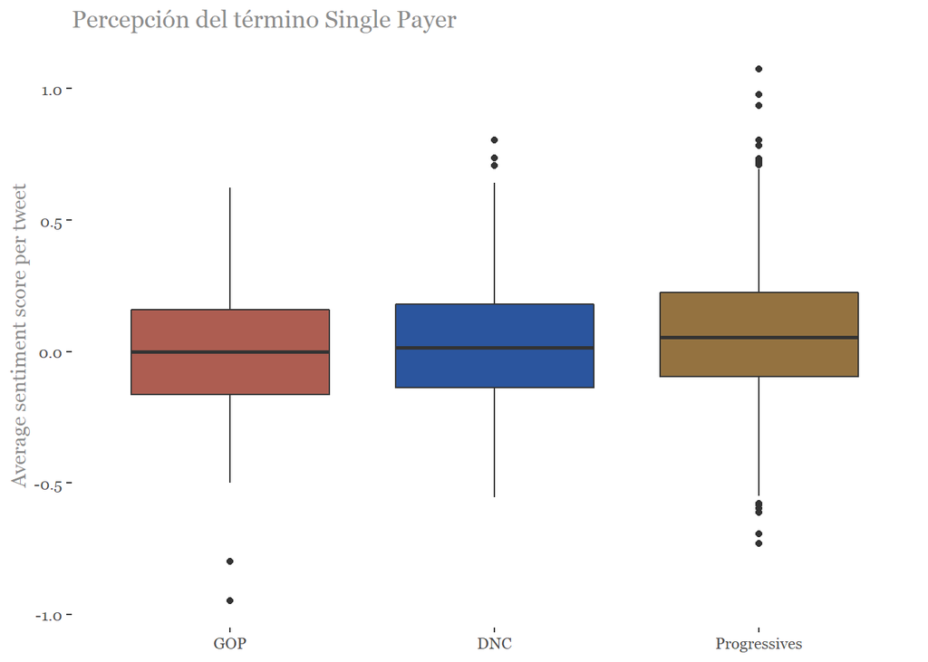

```r
sp %>%
  filter(comunidad != "Independent") %>%
  ggplot(aes(x = comunidad, y = ave_sentiment)) +
  geom_boxplot(aes(fill = comunidad)) +
 scale_fill_manual(values = plots_palette[c(1, 3, 4)]) +
  labs(title = "Percepción del término Single Payer",
       y = "Average sentiment score per tweet") +
  theme_bw() +
  guides(fill = F) +
  theme(
    text = element_text(color = "grey55", family = "Georgia"),
    axis.title.x = element_blank(),
    panel.grid = element_blank(),
    panel.border = element_blank())
```

La percepción de la política “Single Payer” por parte de los republicanos parece ser negativa. Aunque demócratas y progresistas tienen una percepción positiva, los progresistas parecen ver mejor esta política, aunque como se ve en los diagramas de caja, estas diferencias no parecen ser muy importantes.

Realizaremos un test de diferencias de medias para comprobar si estas diferencias son estadísticamente significativas, mediante replicaciones bootstrap de las muestras originales, calculando los intervalos de confianza de las distribuciones empíricas resultantes.

```r
# test diferencias DNC Progressives
test_sp_dnc_prog <- get_test_dif(sp, c("DNC", "Progressives"))
test_sp_dnc_prog[-1]
```

```
## $IC
##                     2.5%      97.5%
## DNC          -0.01039608 0.06296384
## Progressives  0.04843156 0.08415479
##
## $resultado
##                                    97.5%
## "No se encuentran diferencias en medias"
```

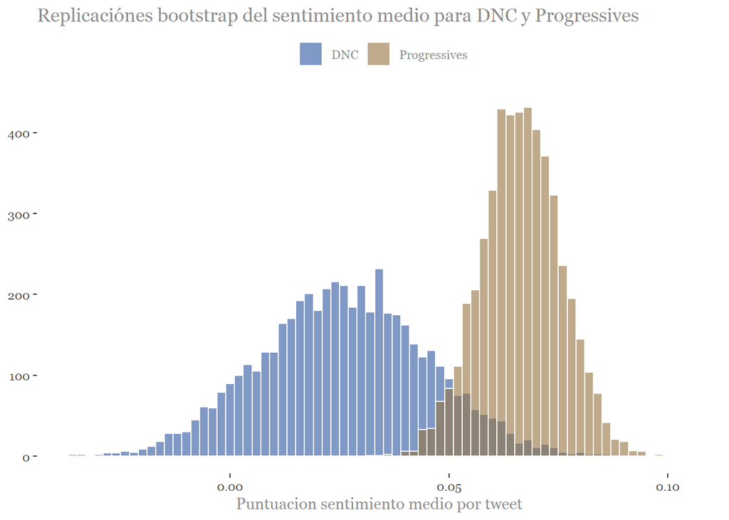

```r
test_sp_dnc_prog$data %>%
ggplot(aes(sentimiento)) +
  geom_histogram(aes(group = comunidad, fill = comunidad), color = "white", position = "identity", alpha = 0.6, binwidth =0.002) +
  scale_fill_manual(values = plots_palette[3:4]) +
  labs(x = "Puntuacion sentimiento medio por tweet",
       title = "Replicaciónes bootstrap del sentimiento medio para DNC y Progressives") +
  theme_bw() +
  theme(panel.grid = element_blank(),
        panel.border = element_blank(),
        legend.title = element_blank(),
        legend.position = "top",
        axis.title.y = element_blank(),
        text = element_text(family = "Georgia", color = "grey55"))
```

No se encuentran diferencias significativas entre demócratas y progresistas

No ocurre lo mismo si se miden las diferencias entre republicanos y progresistas

```r
# test diferencias DNC Progressives
set.seed(123)
test_sp_gop_prog <- get_test_dif(sp, groups = c("GOP", "Progressives"))
test_sp_gop_prog[-1]
```

```
## $IC
##                     2.5%      97.5%
## GOP          -0.04783467 0.03878830
## Progressives  0.04822020 0.08465806
##
## $resultado
## [1] "Diferencia significativa en medias"
```

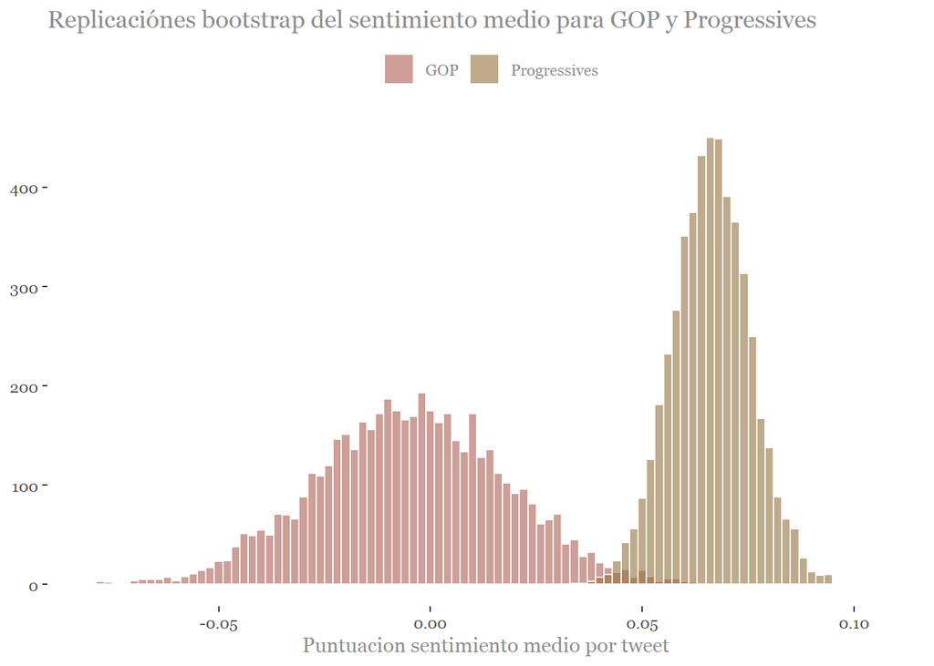

```r
test_sp_gop_prog$data %>%
  ggplot(aes(sentimiento)) +
  geom_histogram(aes(group = comunidad, fill = comunidad), color = "white", position = "identity", alpha = 0.6, binwidth =0.002) +
  scale_fill_manual(values = plots_palette[c(1, 4)]) +
    labs(x = "Puntuacion sentimiento medio por tweet",
       title = "Replicaciónes bootstrap del sentimiento medio para GOP y Progressives") +
  theme_bw() +
  theme(panel.grid = element_blank(),
        panel.border = element_blank(),
        legend.title = element_blank(),
        legend.position = "top",
        axis.title.y = element_blank(),
        text = element_text(family = "Georgia", color = "grey55"))
```

##### Sentimiento expresado hacia ‘Single Payer’ con el diccionario NRC

Si se detallan más las emociones vemos que domina la confianza, pero entre el GOP también hay miedo

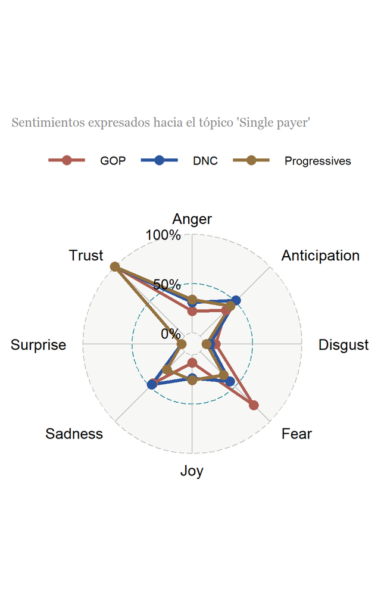

```r
sp_unigram <- get_unigrams(sp %>% filter(comunidad != "Independent"), filter_regular_expression = exclusion_sp) %>%
  mutate(word = str_remove(word, "^#"))

sp_nrc <- sp_unigram %>%
  inner_join(get_sentiments("nrc"), by = "word") %>%
  filter(!sentiment %in% c("positive", "negative")) %>%
  count(comunidad, sentiment, sort = T) %>%
  mutate(sentiment = str_to_title(sentiment)) %>%
  ungroup() %>%
  group_by(comunidad) %>%
  mutate(n = rescale(n)) %>%
  pivot_wider(names_from = sentiment, values_from = n) %>%
  select(comunidad, Anger, Anticipation, Disgust, Fear, Joy, Sadness, Surprise, Trust) %>%
  ungroup() %>%
  mutate(comunidad = fct_drop(comunidad))

ggradar(sp_nrc, group.colours = plots_palette[c(1, 3, 4)], legend.position = "top",
        group.point.size = 4,
        plot.title = "Sentimientos expresados hacia el tópico 'Single payer'",
        legend.text.size = 11) +
  theme(plot.title = element_text(size = 12, family = "Georgia", color = "grey55"),
        axis.title = element_text(family = "Georgia"))
```

Hay cierto grado de polarización entre demócratas y republicanos, pero no así entre demócratas y progresistas.

```r
pol_test_dif <- readRDS(here::here("datos_procesados", "formated_polarization_df_data", "polarization_testing", "health_polarization.rds"))

pol_test_dif[-1]
```

```
## $IC
##                2.5%       97.5%
## DNC-GOP  0.04959839  0.06998175
## DNC-PRG -0.03122013 -0.01980064
##
## $resultado
## [1] "Diferencia significativa en medias"
```

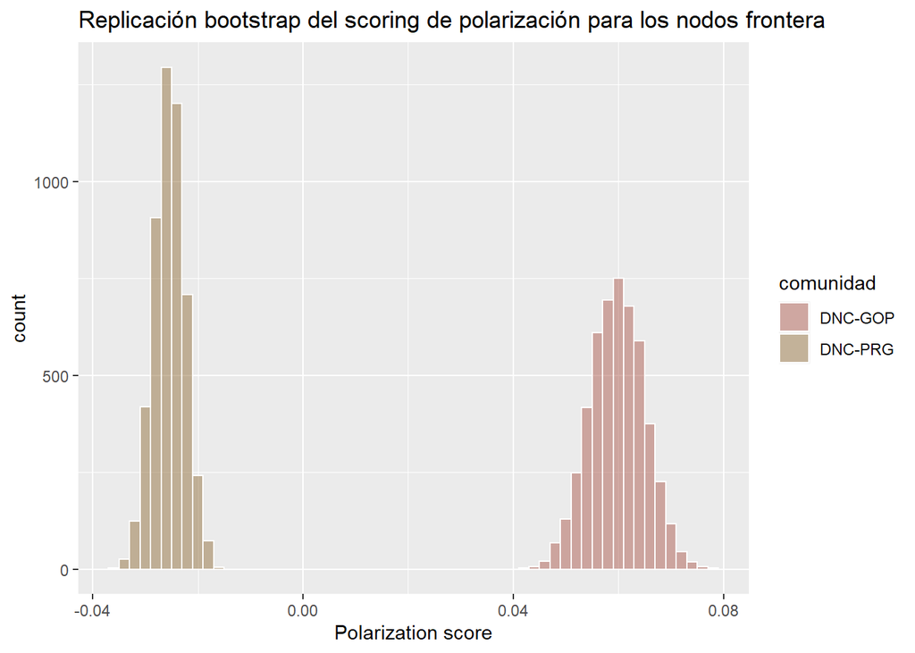

```r
# Nivel de polarizacion mínimo en ambos casos pero se hallan diferencias significativas
pol_test_dif$data %>%
  ggplot(aes(x = sentimiento)) +
  geom_histogram(aes(group = comunidad, fill = comunidad), color = "white", alpha = 0.5, binwidth = 0.002, position = "identity") +
  scale_fill_manual(values = c(plots_palette[1], plots_palette[4])) +
  labs(x = "Polarization score", title = "Replicación bootstrap del scoring de polarización para los nodos frontera")
```